# Report

RTD Mini Project - Group 3

Team members:  
Sulekha Aloorravi  
Suraj Kumar  
Siddhartha Murthy  
Maheshwaran Sridharan  
Sunil Vikram

**Problem Statement:**

Sentiment Analysis on Twitter in Real Time:  
On the real time tweets streams data apply Sentiment Analysis to get the opinion & trends on different topics in real time. Also find influential people or POI (person of Interest) from the twitter data.

**Approach:**

1. Find Influential people in twitter:  
1.1. For simplicity assume the algorithm to find influential person is directly proportional to followers.  
1.2. Find top 20 Influential personalities from the twitter across the globe.

```python
#Python script
import os
import tweepy
from tweepy import OAuthHandler
from tweepy import Stream
from tweepy.streaming import StreamListener
import socket
import json
import requests
import requests_oauthlib

consumer_key = 'SntKtNL6Cuatgnz1Oa7ImyY5D'
consumer_secret = 'DI89nzONJClhLKxoHmwbuAk13aqstKHjTtIvKB0y7z0SHUzm16'
access_token = '911915238173188597-tH2ykrtqmo5UmAjehwxAZFMVDWzouuC'
access_secret = 'CAblWrnbvFLGNCPRDp8uvevayD0GM6sAbCWXvlVItF9xl'

class TweetsListener(StreamListener):

    def __init__(self, csocket):
        self.client_socket = csocket

    def on_data(self, data):
        try:
             msg = json.loads(data)
             if 'user' in msg:
                 self.client_socket.send(msg['user']['screen_name'].encode('utf-8')+'||'+str(msg['user']['followers_count'])+'||'+msg['user']['lang'].encode('utf-8')+'||'+str(msg['user']['statuses_count'])+'||'+msg['place']['country_code'].encode('utf-8')+'||'+str(msg['retweet_count'])+'\n')
        except BaseException as e:
            print("Error on_data: %s" % str(e))
        return True

    def on_error(self, status):
        print(status)
        return True

def sendData(c_socket):
    auth = OAuthHandler(consumer_key, consumer_secret)
    auth.set_access_token(access_token, access_secret)

    twitter_stream = Stream(auth, TweetsListener(c_socket))
    #This below mentioned location coordinates covers the whole world data
    twitter_stream.filter(locations=[-180,-90,180,90])

if __name__ == "__main__":
    s = socket.socket()     # Create a socket object
    host = "192.168.244.136"      # Get local machine name
    port = 5551             # Reserve a port for your service.
    s.bind((host, port))    # Bind to the port

    print("Listening on port: %s" % str(port))

    s.listen(5)                 # Now wait for client connection.
    c, addr = s.accept()        # Establish connection with client.

    print( "Received request from: " + str( addr ) )

    sendData( c )
```

Listening on port: 5551 Received request from: ('192.168.244.136', 54286)

```python
#Spark Streaming
from __future__ import print_function
import sys
from pyspark import SparkContext
from pyspark.streaming import StreamingContext
from pyspark.sql import Row, SparkSession
import io
import requests

def getSparkSessionInstance(sparkConf):
    if ('sparkSessionSingletonInstance' not in globals()):
        globals()['sparkSessionSingletonInstance'] = SparkSession\
            .builder\
            .config(conf=sparkConf)\
            .getOrCreate()
    return globals()['sparkSessionSingletonInstance']


if __name__ == "__main__":
    host, port = sys.argv[1:]
    sc = SparkContext.getOrCreate()
    ssc = StreamingContext(sc, 5)

socket_stream = ssc.socketTextStream("192.168.244.136", 5551)

lines = socket_stream.window(60)

tweets = lines.flatMap(lambda line: line.split("\n"))

# Convert RDDs of the words DStream to DataFrame and run SQL query
def process(time, rdd):
        print("========= %s =========" % str(time))
        from pyspark.sql.types import NumericType
        try:
            # Get the singleton instance of SparkSession
            spark = getSparkSessionInstance(rdd.context.getConf())

            header = ["ScreenName","FollowersCount","Language","TweetsCount","CountryCode","RetweetCount"]
            rowRdd = rdd.map(lambda row : row.split("||"))
            jsonDataFrame = spark.createDataFrame(rowRdd, header)
            jsonDataFrame = jsonDataFrame.withColumn("FollowersCount",jsonDataFrame["FollowersCount"].cast("Int"))
            jsonDataFrame = jsonDataFrame.withColumn("TweetsCount",jsonDataFrame["TweetsCount"].cast("Int"))
            jsonDataFrame = jsonDataFrame.withColumn("RetweetCount",jsonDataFrame["RetweetCount"].cast("Int"))

            # Creates a temporary view using the DataFrame.
            jsonDataFrame.createOrReplaceTempView("tweets")

            # Do word count on table using SQL and print it
            #1.Find Influential people in twitter:
            #1.1 For simplicity assume the algorithm to find influential person is directly proportional to followers.
            #1.2 Find top 20 Influential personalities from the twitter across the globe.
            FollowersCountDF = \
            spark.sql("select ScreenName, FollowersCount from tweets order by FollowersCount desc limit 20")
            FollowersCountDF.show()
            send_df_to_dashboard(FollowersCountDF)

        except:
            pass

def send_df_to_dashboard(df):
    # extract the hashtags from dataframe and convert them into array
    top_tags = [str(t.ScreenName) for t in df.select("ScreenName").collect()]
    # extract the counts from dataframe and convert them into array
    tags_count = [p.FollowersCount for p in df.select("FollowersCount").collect()]
    # initialize and send the data through REST API
    url = 'http://192.168.244.136:5001/updateData'
    request_data = {'label': str(top_tags), 'data': str(tags_count)}
    response = requests.post(url, data=request_data)

tweets.foreachRDD(process)

ssc.start()

ssc.awaitTermination()
```

========= 2017-10-07 01:42:40 ========= ========= 2017-10-07 01:42:45 ========= ========= 2017-10-07 01:42:50 ========= ========= 2017-10-07 01:42:55 ========= +----------+--------------+ |ScreenName|FollowersCount| +----------+--------------+ | MyoGrupo| 17| +----------+--------------+ ========= 2017-10-07 01:43:00 ========= +---------------+--------------+ | ScreenName|FollowersCount| +---------------+--------------+ | lafm| 1882070| | yunusgunce| 107834| | TrendsLima| 106919| | grantstern| 28271| | nacho991960| 24708| | BasquetManresa| 23841| | pfvrmikael| 19112| | TrendsSantiago| 16263| | JoaquinNarro| 15367| | sandysamayra| 13232| | Pra_Raquell| 10509| | NJEstates2| 10343| | Hlomani_Job| 9962| |amirali71457249| 8340| | Oilplated| 7322| | realgiftsambo| 7037| |Germantownrunne| 6931| | arielldelis| 5145| | X_Mookieeee| 5040| | Tessa_25| 4847| +---------------+--------------+ ========= 2017-10-07 01:43:05 ========= +---------------+--------------+ | ScreenName|FollowersCount| +---------------+--------------+ | lafm| 1882070| | sky1| 346457| | caval100| 122215| |ObrasPublicasEc| 116983| | yunusgunce| 107834| | TrendsLima| 106919| | Mad_Hatter_Tea| 51647| | KWCONTINENTE| 43546| | kamalakood| 37954| | EGMorenoR| 31220| | grantstern| 28271| |RobTrainSystems| 26250| | nacho991960| 24708| | BasquetManresa| 23841| | armanwalker| 22783| | vivian| 21426| | grahamelwood| 19561| | pfvrmikael| 19112| | Qallaf94| 17665| | TrendsSantiago| 16263| +---------------+--------------+

2. Get trending Topics in twitter right now:  
2.1 Find the word from the tweet which is occurring most of the times in the whole tweets corpus.  
2.2 Top 10 trending topic.

```python
#2.1. Find the word from the tweet which is occurring most of the times in the whole tweets corpus.
#Python
def clean_tweet(tweet):
        return ' '.join(re.sub("(@[A-Za-z0-9]+)|([^0-9A-Za-z \t])|(\w+:\/\/\S+)", " ", tweet).split())

class TweetsListener(StreamListener):

  def __init__(self, csocket):
      self.client_socket = csocket

  def on_data(self, data):
      try:
          msg = json.loads( data )
          #print( msg['text'].encode('utf-8') )
          tweet_text = clean_tweet(msg['text'])
          #print(tweet_text)
          self.client_socket.send( tweet_text + '\n' )
          return True
      except BaseException as e:
          print("Error on_data: %s" % str(e))
      return True

  def on_error(self, status):
      print(status)
      return True

def sendData(c_socket):
  auth = OAuthHandler(consumer_key, consumer_secret)
  auth.set_access_token(access_token, access_secret)

  twitter_stream = Stream(auth, TweetsListener(c_socket))
  #Use the below line to get whole world's trending topics
  #twitter_stream.filter(locations=[-180,-90,180,90])
  #Due to too much of tweets volume and execution time, I am using the below line to get output
  #twitter_stream.filter(track=['iphone'])
  twitter_stream.sample()
```

Listening on port: 7799 Received request from: ('192.168.244.136', 47812)

```python
#Spark
nonempty_lines = lines.filter(lambda x: len(x) > 0)
words = nonempty_lines.flatMap(lambda x: x.split(" "))
def send_df_to_dashboard(df):
    # extract the hashtags from dataframe and convert them into array
    top_tags = [str(t.word_tweet) for t in df.select("word_tweet").collect()]
    # extract the counts from dataframe and convert them into array
    tags_count = [p.Count for p in df.select("Count").collect()]
    # initialize and send the data through REST API
    url = 'http://192.168.244.136:5001/updateData'
    request_data = {'label': str(top_tags), 'data': str(tags_count)}
    response = requests.post(url, data=request_data)
def get_tweets(time, rdd):
    print("========= %s =========" % str(time))
    from pyspark.sql.types import NumericType
    try:
        header = ["word_tweet"]
        spark = getSparkSessionInstance(rdd.context.getConf())
        Rowrdd = rdd.map(lambda x: x.split("\n"))
        jsonDataFrame = spark.createDataFrame(Rowrdd,header)
        df = jsonDataFrame.where(~jsonDataFrame.word_tweet.isin("RT","a","you","the","to","de","s","and","is","on","t","I","of","for","o","this","i","that","e","it","m","que","la","en"))
        df.createOrReplaceTempView("tweets")
        TrendTweetDF = \
        spark.sql("select word_tweet,count(*) as Count from tweets group by word_tweet order by count(*) desc limit 10")
        TrendTweetDF.show()
        send_df_to_dashboard(TrendTweetDF)
    except:
            pass
words.foreachRDD(get_tweets)
ssc.start()
```

========= 2017-10-08 12:34:35 ========= +----------+-----+ |word_tweet|Count| +----------+-----+ | at| 30| | w| 10| | The| 9| | do| 9| | gt| 9| | my| 8| | your| 7| | he| 7| | 3| 6| | like| 6| +----------+-----+ ========= 2017-10-08 12:34:40 ========= +----------+-----+ |word_tweet|Count| +----------+-----+ | at| 18| | my| 7| | we| 7| | are| 6| | The| 6| | 10| 6| | 3| 6| | shit| 5| | his| 5| | but| 5| +----------+-----+

```python
#2.2 Top 10 Trending Topics in real time
#Python
class TweetsListener(StreamListener):

  def __init__(self, csocket):
      self.client_socket = csocket

  def on_data(self, data):
      try:
          msg = json.loads( data )
          #print( msg['text'].encode('utf-8') )
          #tweet_text = clean_tweet(msg['text'])
          #print(tweet_text)
          self.client_socket.send( msg['text'].encode('utf-8') + '\n' )
          return True
      except BaseException as e:
          print("Error on_data: %s" % str(e))
      return True

  def on_error(self, status):
      print(status)
      return True

def sendData(c_socket):
  auth = OAuthHandler(consumer_key, consumer_secret)
  auth.set_access_token(access_token, access_secret)

  twitter_stream = Stream(auth, TweetsListener(c_socket))
  #Use the below line to get whole world's trending topics
  twitter_stream.filter(locations=[-180,-90,180,90])
  #Due to too much of tweets volume and execution time, I am using the below line to get output
  #twitter_stream.filter(track=['iphone'])
  #twitter_stream.sample()
```

```python
#Spark
hashtags = lines.flatMap(lambda text: text.split(" ")).filter(lambda word: word.lower().startswith("#"))
def send_df_to_dashboard(df):
    # extract the hashtags from dataframe and convert them into array
    top_tags = [str(t.topic_tweet) for t in df.select("topic_tweet").collect()]
    # extract the counts from dataframe and convert them into array
    tags_count = [p.Count for p in df.select("Count").collect()]
    # initialize and send the data through REST API
    url = 'http://192.168.244.136:5001/updateData'
    request_data = {'label': str(top_tags), 'data': str(tags_count)}
    response = requests.post(url, data=request_data)
def get_tweets(time, rdd):
    print("========= %s =========" % str(time))
    from pyspark.sql.types import NumericType
    try:
        header = ["topic_tweet"]
        spark = getSparkSessionInstance(rdd.context.getConf())
        Rowrdd = rdd.map(lambda x: x.split("\n"))
        jsonDataFrame = spark.createDataFrame(Rowrdd,header)
        jsonDataFrame.createOrReplaceTempView("tweets")
        TrendTweetDF = \
        spark.sql("select topic_tweet,count(*) as Count from tweets group by topic_tweet order by count(*) desc limit 10")
        TrendTweetDF.show()
        send_df_to_dashboard(TrendTweetDF)
    except:
            pass
hashtags.foreachRDD(get_tweets)
ssc.start()
```

========= 2017-10-08 03:53:45 ========= +----------------+-----+ | topic_tweet|Count| +----------------+-----+ | #Hiring| 9| | #job| 5| | #CareerArc| 4| | #ARKvsSC| 4| | #Job| 3| | #Jobs| 2| | #job?| 2| | #Automotive| 2| |#ALDUBHeartsCare| 2| | #foodporn| 2| +----------------+-----+ ========= 2017-10-08 03:53:50 ========= +----------------+-----+ | topic_tweet|Count| +----------------+-----+ | #job| 9| | #Hiring| 9| | #job?| 4| | #CareerArc| 3| | #foodporn| 2| | #Houston,| 2| | #ARKvsSC| 2| |#ALDUBHeartsCare| 2| | #Job| 2| |#CustomerService| 2| +----------------+-----+

3. Sentiment Analysis:  
3.1. Filter tweets & take tweets which has mention of “iphone”.  
3.2. Get sentiments about iphone every hour.

```python
#Python
import os
import tweepy
from tweepy import OAuthHandler
from tweepy import Stream
from tweepy.streaming import StreamListener
import socket
import json
import requests
import requests_oauthlib

consumer_key = 'SntKtNL6Cuatgnz1Oa7ImyY5D'
consumer_secret = 'DI89nzONJClhLKxoHmwbuAk13aqstKHjTtIvKB0y7z0SHUzm16'
access_token = '911915238173188597-tH2ykrtqmo5UmAjehwxAZFMVDWzouuC'
access_secret = 'CAblWrnbvFLGNCPRDp8uvevayD0GM6sAbCWXvlVItF9xl'

class TweetsListener(StreamListener):

    def __init__(self, csocket):
        self.client_socket = csocket

    def on_data(self, data):
        try:
             msg = json.loads(data)
             #if 'user' in msg:
             self.client_socket.send(msg['text'].encode('utf-8')+'\n')
        except BaseException as e:
            print("Error on_data: %s" % str(e))
        return True

    def on_error(self, status):
        print(status)
        return True

def sendData(c_socket):
    auth = OAuthHandler(consumer_key, consumer_secret)
    auth.set_access_token(access_token, access_secret)

    twitter_stream = Stream(auth, TweetsListener(c_socket))
    twitter_stream.filter(track=['iphone'])
    #twitter_stream.filter(locations=[-180,-90,180,90])
    #twitter_stream.sample()
if __name__ == "__main__":
    s = socket.socket()     # Create a socket object
    host = "192.168.244.136"      # Get local machine name
    port = 5555            # Reserve a port for your service.
    s.bind((host, port))    # Bind to the port

    print("Listening on port: %s" % str(port))

    s.listen(5)                 # Now wait for client connection.
    c, addr = s.accept()        # Establish connection with client.

    print( "Received request from: " + str( addr ) )

    sendData( c )
```

Listening on port: 5555 Received request from: ('192.168.244.136', 53566)

```python
#Spark
from __future__ import print_function
import sys
from pyspark import SparkContext
from pyspark.streaming import StreamingContext
from pyspark.sql import Row, SparkSession
import io
import requests
import re
from textblob import TextBlob

def getSparkSessionInstance(sparkConf):
    if ('sparkSessionSingletonInstance' not in globals()):
        globals()['sparkSessionSingletonInstance'] = SparkSession\
            .builder\
            .config(conf=sparkConf)\
            .getOrCreate()
    return globals()['sparkSessionSingletonInstance']


if __name__ == "__main__":
    #if len(sys.argv) != 3:
     #   print("Usage: sql_network_wordcount.py <hostname> <port> ", file=sys.stderr)
      #   exit(-1)
    #host, port = sys.argv[1:]
    sc = SparkContext.getOrCreate()
    #Enter 3600 to get iphone sentiments for every hour.
    ssc = StreamingContext(sc, 60)
    #To receive more and quicker output for reporting purpose I have used 60 here.

socket_stream = ssc.socketTextStream("192.168.244.136", 5555)

#Enter 3600 to get iphone sentiments for every hour.
#To receive more and quicker output for reporting purpose I have used 60 here.
lines = socket_stream.window(60)

def clean_tweet(tweet):
        return ' '.join(re.sub("(@[A-Za-z0-9]+)|([^0-9A-Za-z \t])|(\w+:\/\/\S+)", " ", tweet).split())

def get_tweet_sentiment(tweet):
        # create TextBlob object of passed tweet text
        analysis = TextBlob(clean_tweet(tweet))
        # set sentiment
        if analysis.sentiment.polarity > 0:
            return 'positive'
        elif analysis.sentiment.polarity == 0:
            return 'neutral'
        else:
            return 'negative'

def send_df_to_dashboard(df):
    # extract the hashtags from dataframe and convert them into array
    top_tags = [str(t.Sentiment) for t in df.select("Sentiment").collect()]
    # extract the counts from dataframe and convert them into array
    tags_count = [p.Count for p in df.select("Count").collect()]
    # initialize and send the data through REST API
    url = 'http://192.168.244.136:5001/updateData'
    request_data = {'label': str(top_tags), 'data': str(tags_count)}
    response = requests.post(url, data=request_data)

tweety = lines.flatMap(lambda line: line.split("\n"))

def get_tweets(time, rdd):
        print("========= %s =========" % str(time))
        from pyspark.sql.types import NumericType
        try:
            header = ["Tweet"]
            spark = getSparkSessionInstance(rdd.context.getConf())
            spark.udf.register('get_tweet_sentiment', get_tweet_sentiment)
            rowRdd = rdd.map(lambda row: row.split("\n"))
            jsonDataFrame = spark.createDataFrame(rowRdd, header)
            jsonDataFrame.createOrReplaceTempView("tweets")
            #2. Sentiment Analysis:
            #2.1 Filter tweets & take tweets which has mention of “iphone”.
            iPhoneTweetDF = \
            spark.sql("select Tweet, get_tweet_sentiment(Tweet) as Sentiment from tweets")
            iPhoneTweetDF.show()
            sentiCountDF = \
            spark.sql("select get_tweet_sentiment(Tweet) as Sentiment, count(get_tweet_sentiment(Tweet)) as Count from tweets group by get_tweet_sentiment(Tweet)")
            sentiCountDF.show()
            send_df_to_dashboard(sentiCountDF)
        except:
            pass

tweety.foreachRDD(get_tweets)
ssc.start()
ssc.awaitTermination()
```

========= 2017-10-07 15:23:00 ========= +--------------------+---------+ | Tweet|Sentiment| +--------------------+---------+ |モイ！初見さんどうぞiPhoneか...| neutral| |モイ！iPhoneからキャス配信中...| neutral| |ジョナサン・アイブ氏が語った「iP...| neutral| |¡Participo en el ...| neutral| |¿Nos das un RT? #...| neutral| |RT @Apple: iPhone...| positive| |RT @LeshaLappar: ...| neutral| |также делаю ремон...| neutral| | やべ、電池切れだぜ| neutral| |iPhoneを電池切れっていう表現...| neutral| |RT @businessinsid...| neutral| |RT @yannoujr10: L...| neutral| |RT @iPhone8Promo1...| positive| |https://t.co/wZQU...| neutral| | | neutral| | #280character| neutral| | #NationalPoetryDay| neutral| |RT @MochiManggae:...| neutral| |RT @MochiManggae:...| neutral| |Mobioutlet Apple ...| negative| +--------------------+---------+ only showing top 20 rows +---------+-----+ |Sentiment|Count| +---------+-----+ | positive| 22| | neutral| 670| | negative| 9| +---------+-----+

4. Geo based analysis:  
4.1. Country based tweets count.  
4.2. Top countries in terms of Tweets Volume.  
4.3. List of top 15 countries in terms of tweet counts.

```python
#Python
import os
import tweepy
from tweepy import OAuthHandler
from tweepy import Stream
from tweepy.streaming import StreamListener
import socket
import json
import requests
import requests_oauthlib

consumer_key = 'SntKtNL6Cuatgnz1Oa7ImyY5D'
consumer_secret = 'DI89nzONJClhLKxoHmwbuAk13aqstKHjTtIvKB0y7z0SHUzm16'
access_token = '911915238173188597-tH2ykrtqmo5UmAjehwxAZFMVDWzouuC'
access_secret = 'CAblWrnbvFLGNCPRDp8uvevayD0GM6sAbCWXvlVItF9xl'

class TweetsListener(StreamListener):

    def __init__(self, csocket):
        self.client_socket = csocket

    def on_data(self, data):
        try:
            msg = json.loads(data)
            if 'user' in msg:
                 self.client_socket.send(msg['user']['screen_name'].encode('utf-8')+'||'+str(msg['user']['followers_count'])+'||'+msg['user']['lang'].encode('utf-8')+'||'+str(msg['user']['statuses_count'])+'||'+msg['place']['country_code'].encode('utf-8')+'\n')
            return True
        except BaseException as e:
            print("Error on_data: %s" % str(e))
        return True

    def on_error(self, status):
        print(status)
        return True

def sendData(c_socket):
    auth = OAuthHandler(consumer_key, consumer_secret)
    auth.set_access_token(access_token, access_secret)

    twitter_stream = Stream(auth, TweetsListener(c_socket))
    #This below mentioned location coordinates covers the whole world data
    twitter_stream.filter(locations=[-180,-90,180,90])

if __name__ == "__main__":
    s = socket.socket()     # Create a socket object
    host = "192.168.244.136"      # Get local machine name
    port = 5552             # Reserve a port for your service.
    s.bind((host, port))    # Bind to the port

    print("Listening on port: %s" % str(port))

    s.listen(5)                 # Now wait for client connection.
    c, addr = s.accept()        # Establish connection with client.

    print( "Received request from: " + str( addr ) )

    sendData( c )
```

Listening on port: 5552 Received request from: ('192.168.244.136', 42954)

```python
#Spark
from __future__ import print_function
import sys
from pyspark import SparkContext
from pyspark.streaming import StreamingContext
from pyspark.sql import Row, SparkSession
import io
import requests

def getSparkSessionInstance(sparkConf):
    if ('sparkSessionSingletonInstance' not in globals()):
        globals()['sparkSessionSingletonInstance'] = SparkSession\
            .builder\
            .config(conf=sparkConf)\
            .getOrCreate()
    return globals()['sparkSessionSingletonInstance']


if __name__ == "__main__":
    sc = SparkContext.getOrCreate()
    ssc = StreamingContext(sc, 5)

socket_stream = ssc.socketTextStream("192.168.244.136", 5552)

lines = socket_stream.window(60)

tweets = lines.flatMap(lambda line: line.split("\n"))

# Convert RDDs of the words DStream to DataFrame and run SQL query
def process(time, rdd):
        print("========= %s =========" % str(time))
        from pyspark.sql.types import NumericType
        try:
            # Get the singleton instance of SparkSession
            spark = getSparkSessionInstance(rdd.context.getConf())

            header = ["ScreenName","FollowersCount","Language","TweetsCount","CountryCode"]
            rowRdd = rdd.map(lambda row : row.split("||"))
            jsonDataFrame = spark.createDataFrame(rowRdd, header)
            jsonDataFrame = jsonDataFrame.withColumn("FollowersCount",jsonDataFrame["FollowersCount"].cast("Int"))
            jsonDataFrame = jsonDataFrame.withColumn("TweetsCount",jsonDataFrame["TweetsCount"].cast("Int"))


            # Creates a temporary view using the DataFrame.
            jsonDataFrame.createOrReplaceTempView("tweets")

            #4.Geo based analysis:
            #4.1 Country based tweets count.
            #4.3 List of top 15 countries in terms of tweet counts.
            CountryCountDF = \
            spark.sql("select CountryCode,TweetsCount  from tweets")
            data = CountryCountDF.groupby('CountryCode').agg({'TweetsCount': 'sum'})
            oldColumns = data.schema.names
            newColumns = ["CountryCode", "TweetVolume"]
            TweetVolumedf = reduce(lambda data, idx: data.withColumnRenamed(oldColumns[idx], newColumns[idx]), xrange(len(oldColumns)), data)
            TweetVolumedf.createOrReplaceTempView("tweetsvol")
            vol_df = \
            spark.sql("select CountryCode, TweetVolume from tweetsvol order by TweetVolume desc limit 15")
            print("Tweets Volume by Country")
            vol_df.show()
            send_df_to_dashboard1(vol_df)

            data = CountryCountDF.groupby('CountryCode').agg({'CountryCode': 'count'})
            oldColumns = data.schema.names
            newColumns = ["CountryCode", "TweetCount"]
            TweetVolumedf = reduce(lambda data, idx: data.withColumnRenamed(oldColumns[idx], newColumns[idx]), xrange(len(oldColumns)), data)
            TweetVolumedf.createOrReplaceTempView("tweetscnt")
            cnt_df = \
            spark.sql("select CountryCode, TweetCount from tweetscnt order by TweetCount desc limit 15")
            print("Tweets Count by Country")
            cnt_df.show()
            send_df_to_dashboard2(cnt_df)



        except:
            pass

def send_df_to_dashboard1(df):
    # extract the hashtags from dataframe and convert them into array
    top_tags = [str(t.CountryCode) for t in df.select("CountryCode").collect()]
    # extract the counts from dataframe and convert them into array
    tags_count = [p.TweetVolume for p in df.select("TweetVolume").collect()]
    # initialize and send the data through REST API
    url = 'http://192.168.244.136:5001/updateData'
    request_data = {'label': str(top_tags), 'data': str(tags_count)}
    response = requests.post(url, data=request_data)

def send_df_to_dashboard2(df):
    # extract the hashtags from dataframe and convert them into array
    top_tags = [str(t.CountryCode) for t in df.select("CountryCode").collect()]
    # extract the counts from dataframe and convert them into array
    tags_count = [p.TweetCount for p in df.select("TweetCount").collect()]
    # initialize and send the data through REST API
    url = 'http://192.168.244.136:5002/updateData'
    request_data = {'label': str(top_tags), 'data': str(tags_count)}
    response = requests.post(url, data=request_data)

tweets.foreachRDD(process)

ssc.start()

ssc.awaitTermination()
```

========= 2017-10-07 17:06:00 ========= +-----------+-----------+ |CountryCode|TweetVolume| +-----------+-----------+ | JP| 1177246| | BR| 1092785| | GB| 789087| | AR| 561868| | US| 521329| | ES| 441202| | PH| 423445| | KW| 280345| | FR| 269826| | TH| 251683| | CL| 248782| | UY| 228050| | DE| 202578| | MY| 196865| | PT| 171694| +-----------+-----------+ ========= 2017-10-07 17:15:55 ========= +-----------+----------+ |CountryCode|TweetCount| +-----------+----------+ | US| 18| | JP| 12| | PH| 11| | BR| 11| | GB| 10| | ES| 7| | FR| 7| | ZA| 5| | SE| 3| | PT| 3| | AU| 3| | ID| 2| | MY| 2| | AT| 2| | IN| 2| +-----------+----------+ ========= 2017-10-07 17:16:00 ========= +-----------+----------+ |CountryCode|TweetCount| +-----------+----------+ | US| 44| | BR| 35| | JP| 33| | GB| 28| | PH| 24| | FR| 15| | ES| 15| | TH| 10| | MY| 9| | IN| 8| | ZA| 8| | TR| 8| | ID| 6| | RU| 5| | SA| 5| +-----------+----------+

5. Find Top tweeting user:  
5.1. Find User who is tweeting a lot.  
5.2. Find top 50 across the world.

```python
#Python
import os
import tweepy
from tweepy import OAuthHandler
from tweepy import Stream
from tweepy.streaming import StreamListener
import socket
import json
import requests
import requests_oauthlib

consumer_key = 'SntKtNL6Cuatgnz1Oa7ImyY5D'
consumer_secret = 'DI89nzONJClhLKxoHmwbuAk13aqstKHjTtIvKB0y7z0SHUzm16'
access_token = '911915238173188597-tH2ykrtqmo5UmAjehwxAZFMVDWzouuC'
access_secret = 'CAblWrnbvFLGNCPRDp8uvevayD0GM6sAbCWXvlVItF9xl'

class TweetsListener(StreamListener):

    def __init__(self, csocket):
        self.client_socket = csocket

    def on_data(self, data):
        try:
            msg = json.loads(data)
            if 'user' in msg:
                 self.client_socket.send(msg['user']['screen_name'].encode('utf-8')+'||'+str(msg['user']['followers_count'])+'||'+msg['user']['lang'].encode('utf-8')+'||'+str(msg['user']['statuses_count'])+'||'+msg['place']['country_code'].encode('utf-8')+'\n')
            return True
        except BaseException as e:
            print("Error on_data: %s" % str(e))
        return True

    def on_error(self, status):
        print(status)
        return True

def sendData(c_socket):
    auth = OAuthHandler(consumer_key, consumer_secret)
    auth.set_access_token(access_token, access_secret)

    twitter_stream = Stream(auth, TweetsListener(c_socket))
    #This below mentioned location coordinates covers the whole world data
    twitter_stream.filter(locations=[-180,-90,180,90])

if __name__ == "__main__":
    s = socket.socket()     # Create a socket object
    host = "192.168.244.136"      # Get local machine name
    port = 5559             # Reserve a port for your service.
    s.bind((host, port))    # Bind to the port

    print("Listening on port: %s" % str(port))

    s.listen(5)                 # Now wait for client connection.
    c, addr = s.accept()        # Establish connection with client.

    print( "Received request from: " + str( addr ) )

    sendData( c )
```

Listening on port: 5559 Received request from: ('192.168.244.136', 56914)

```python
#Below coding is the Spark logic and I am not repeating connection attributes
tweets = lines.flatMap(lambda line: line.split("\n"))
# Convert RDDs of the words DStream to DataFrame and run SQL query
def process(time, rdd):
        print("========= %s =========" % str(time))
        from pyspark.sql.types import NumericType
        try:
            # Get the singleton instance of SparkSession
            spark = getSparkSessionInstance(rdd.context.getConf())

            header = ["ScreenName","FollowersCount","Language","TweetsCount","CountryCode"]
            rowRdd = rdd.map(lambda row : row.split("||"))
            jsonDataFrame = spark.createDataFrame(rowRdd, header)
            jsonDataFrame = jsonDataFrame.withColumn("FollowersCount",jsonDataFrame["FollowersCount"].cast("Int"))
            jsonDataFrame = jsonDataFrame.withColumn("TweetsCount",jsonDataFrame["TweetsCount"].cast("Int"))


            # Creates a temporary view using the DataFrame.
            jsonDataFrame.createOrReplaceTempView("tweets")
            #5. Find Top tweeting user:
            #5.1 Find User who is tweeting a lot.
            #5.2 Find top 50 across the world.

            TweetCountDF = \
            spark.sql("select ScreenName,TweetsCount  from tweets order by TweetsCount desc limit 50")
            TweetCountDF.show()
            send_df_to_dashboard(TweetCountDF)

        except:
            pass

def send_df_to_dashboard(df):
    # extract the hashtags from dataframe and convert them into array
    top_tags = [str(t.ScreenName) for t in df.select("ScreenName").collect()]
    # extract the counts from dataframe and convert them into array
    tags_count = [p.TweetsCount for p in df.select("TweetsCount").collect()]
    # initialize and send the data through REST API
    url = 'http://192.168.244.136:5001/updateData'
    request_data = {'label': str(top_tags), 'data': str(tags_count)}
    response = requests.post(url, data=request_data)
tweets.foreachRDD(process)
ssc.start()
ssc.awaitTermination()
```

========= 2017-10-08 13:19:05 ========= +---------------+-----------+ | ScreenName|TweetsCount| +---------------+-----------+ | 511NY| 2542288| | 511NYMidHudson| 452360| | SvobodaRadio| 207597| | TonyMatsuda| 197591| | goisutokki| 182338| | g008c1088| 162981| | SeanathonOAK| 144895| | saraltareen| 117613| | Jasonkessler16| 80792| | Caligraphy215| 74486| |mili_sagardoyOk| 63985| | Nikkopayton| 61319| | endzoneblog_| 57070| | melkeior| 56654| | MrOddFuture| 56581| | Dire27Li| 56558| |Marceldesrosie1| 54436| | iPreferPurpHoe| 51690| | shaafiqahramli| 49305| | 1_libriana_| 41807| | marocasouz| 41019| | _iAmBuck| 33659| |takatayoshitake| 31823| | LGJRDNS| 29529| | Tina7Dubovec| 24037| | silvarafaelb| 23594| | ReivieBasten| 21525| |Meli_guadalupee| 21466| | CuddyBruh| 21090| | uekiyaryoen| 19895| |oksanacherednik| 18298| | horozz| 17799| | lizzydeLoca| 17290| | MeluDiaz_Ok| 17284| | asrofuu24| 15320| | evaraujos| 15028| | mayra909| 14399| | prynxhenry| 12339| | Peterlowery| 12267| | jonahuhdg| 11371| | PeacefulPure| 10623| | xxtaniaxx| 10510| | ryujisea| 10413| | judeeflick| 10148| | abdullahgotah1| 9945| | rasheed222012| 9771| | Swedrick| 9283| | AlbionnKurtaj| 9219| |astridalcocermn| 7782| | girlsonbws| 7018| +---------------+-----------+

6. Language based analysis:  
6.1. Find counts of tweets in different languages.  
6.2. Get top 7 languages in terms of volume.

```python
#Python
#I have removed all repititive code and mentioning only the logical part here
def on_data(self, data):
        try:
            msg = json.loads(data)
            if 'user' in msg:
                 self.client_socket.send(msg['user']['screen_name'].encode('utf-8')+'||'+str(msg['user']['followers_count'])+'||'+msg['user']['lang'].encode('utf-8')+'||'+str(msg['user']['statuses_count'])+'||'+msg['place']['country_code'].encode('utf-8')+'\n')
            return True
        except BaseException as e:
            print("Error on_data: %s" % str(e))
        return True
```

Listening on port: 5559 Received request from: ('192.168.244.136', 59738)

```python
#Spark
#6.1. Find counts of tweets in different languages.

def process(time, rdd):
        print("========= %s =========" % str(time))
        from pyspark.sql.types import NumericType
        try:
            # Get the singleton instance of SparkSession
            spark = getSparkSessionInstance(rdd.context.getConf())

            header = ["ScreenName","FollowersCount","Language","TweetsCount","CountryCode"]
            rowRdd = rdd.map(lambda row : row.split("||"))
            jsonDataFrame = spark.createDataFrame(rowRdd, header)
            jsonDataFrame = jsonDataFrame.withColumn("FollowersCount",jsonDataFrame["FollowersCount"].cast("Int"))
            jsonDataFrame = jsonDataFrame.withColumn("TweetsCount",jsonDataFrame["TweetsCount"].cast("Int"))


            # Creates a temporary view using the DataFrame.
            jsonDataFrame.createOrReplaceTempView("tweets")

            LangDF = \
            spark.sql("select Language,TweetsCount  from tweets")
            #4.Geo based analysis:
            #4.2 Top countries in terms of Tweets Volume
            data = LangDF.groupby('Language').agg({'TweetsCount': 'count'})
            oldColumns = data.schema.names
            newColumns = ["Language", "TweetCount"]
            TweetVolumedf = reduce(lambda data, idx: data.withColumnRenamed(oldColumns[idx], newColumns[idx]), xrange(len(oldColumns)), data)
            TweetVolumedf.createOrReplaceTempView("tweetscnt")
            vol_df = \
            spark.sql("select Language, TweetCount from tweetscnt order by TweetCount desc limit 15")
            vol_df.show()
            send_df_to_dashboard(vol_df)
        except:
            pass

def send_df_to_dashboard(df):
    # extract the hashtags from dataframe and convert them into array
    top_tags = [str(t.Language) for t in df.select("Language").collect()]
    # extract the counts from dataframe and convert them into array
    tags_count = [p.TweetCount for p in df.select("TweetCount").collect()]
    # initialize and send the data through REST API
    url = 'http://192.168.244.136:5001/updateData'
    request_data = {'label': str(top_tags), 'data': str(tags_count)}
    response = requests.post(url, data=request_data)

tweets.foreachRDD(process)
ssc.start()
ssc.awaitTermination()
```

+--------+----------+ |Language|TweetCount| +--------+----------+ | en| 395| | pt| 89| | ja| 76| | es| 56| | tr| 20| | ar| 15| | fr| 11| | ru| 10| | th| 9| | it| 7| | de| 7| | id| 6| | nl| 4| | ca| 4| | en-gb| 3| +--------+----------+ ========= 2017-10-07 18:32:05 ========= +--------+----------+ |Language|TweetCount| +--------+----------+ | en| 501| | pt| 110| | ja| 91| | es| 69| | tr| 30| | ar| 19| | fr| 17| | ru| 13| | it| 11| | th| 10| | de| 8| | id| 7| | nl| 7| | ca| 4| | en-gb| 3| +--------+----------+ ========= 2017-10-07 18:32:10 ========= +--------+----------+ |Language|TweetCount| +--------+----------+ | en| 586| | pt| 132| | ja| 102| | es| 81| | tr| 35| | ar| 23| | fr| 19| | ru| 16| | th| 13| | it| 12| | id| 10| | de| 9| | nl| 7| | en-gb| 5| | ca| 4| +--------+----------+ ========= 2017-10-07 18:32:15 ========= +--------+----------+ |Language|TweetCount| +--------+----------+ | en| 669| | pt| 154| | ja| 117| | es| 94| | tr| 40| | ar| 27| | fr| 21| | ru| 18| | th| 14| | id| 12| | it| 12| | nl| 9| | de| 9| | en-gb| 8| | ca| 4| +--------+----------+ ========= 2017-10-07 18:32:20 =========

```python
#Spark
#6.2 Get top 7 languages in terms of volume.
def process(time, rdd):
        print("========= %s =========" % str(time))
        from pyspark.sql.types import NumericType
        try:
            # Get the singleton instance of SparkSession
            spark = getSparkSessionInstance(rdd.context.getConf())

            header = ["ScreenName","FollowersCount","Language","TweetsCount","CountryCode"]
            rowRdd = rdd.map(lambda row : row.split("||"))
            jsonDataFrame = spark.createDataFrame(rowRdd, header)
            jsonDataFrame = jsonDataFrame.withColumn("FollowersCount",jsonDataFrame["FollowersCount"].cast("Int"))
            jsonDataFrame = jsonDataFrame.withColumn("TweetsCount",jsonDataFrame["TweetsCount"].cast("Int"))


            # Creates a temporary view using the DataFrame.
            jsonDataFrame.createOrReplaceTempView("tweets")

            LangDF = \
            spark.sql("select Language,TweetsCount  from tweets")
            #4.Geo based analysis:
            #4.2 Top countries in terms of Tweets Volume
            data = LangDF.groupby('Language').agg({'TweetsCount': 'sum'})
            oldColumns = data.schema.names
            newColumns = ["Language", "TweetVolume"]
            TweetVolumedf = reduce(lambda data, idx: data.withColumnRenamed(oldColumns[idx], newColumns[idx]), xrange(len(oldColumns)), data)
            TweetVolumedf.createOrReplaceTempView("tweetsvol")
            vol_df = \
            spark.sql("select Language, TweetVolume from tweetsvol order by TweetVolume desc limit 7")
            vol_df.show()
            send_df_to_dashboard(vol_df)

        except:
            pass
```

========= 2017-10-07 18:59:45 ========= +--------+-----------+ |Language|TweetVolume| +--------+-----------+ | en| 5996971| | pt| 1872450| | ja| 725883| | fr| 383550| | es| 197223| | ar| 111382| | gl| 67282| +--------+-----------+ ========= 2017-10-07 18:59:50 ========= +--------+-----------+ |Language|TweetVolume| +--------+-----------+ | en| 9052869| | pt| 2817133| | ja| 2808881| | es| 486820| | fr| 417724| | da| 254533| | tr| 151961| +--------+-----------+ ========= 2017-10-07 18:59:55 ========= +--------+-----------+ |Language|TweetVolume| +--------+-----------+ | en| 12455222| | ja| 5026451| | pt| 3489876| | es| 1298686| | ar| 457732| | fr| 421425| | it| 415039| +--------+-----------+ ========= 2017-10-07 19:00:00 ========= +--------+-----------+ |Language|TweetVolume| +--------+-----------+ | en| 15804144| | ja| 5889889| | pt| 4536939| | es| 1603492| | fr| 846913| | ar| 523186| | it| 415046| +--------+-----------+

7. Most popular tweets:  
7.1. Most popular tweets means here is the tweet which has been re-tweeted maximum number of times.  
7.2. Get top 100 most re-tweeted tweets in last 1 hour related to “iphone”.

```python
#Python
import os
import tweepy
from tweepy import OAuthHandler
from tweepy import Stream
from tweepy.streaming import StreamListener
import socket
import json
import requests
import requests_oauthlib

consumer_key = 'SntKtNL6Cuatgnz1Oa7ImyY5D'
consumer_secret = 'DI89nzONJClhLKxoHmwbuAk13aqstKHjTtIvKB0y7z0SHUzm16'
access_token = '911915238173188597-tH2ykrtqmo5UmAjehwxAZFMVDWzouuC'
access_secret = 'CAblWrnbvFLGNCPRDp8uvevayD0GM6sAbCWXvlVItF9xl'

class TweetsListener(StreamListener):

    def __init__(self, csocket, num_tweets_to_grab, retweet_count=10000):
        self.client_socket = csocket
        self.counter = 0
        self.num_tweets_to_grab = num_tweets_to_grab
        self.retweet_count = retweet_count

    def on_data(self, data):
        try:
            msg = json.loads(data)
            self.counter += 1
            retweet_count = msg["retweeted_status"]["retweet_count"]
            text_tweet = msg['text'][3:15]
            print(text_tweet)
            if retweet_count >= self.retweet_count:
                #print(msg["text"], retweet_count)
                #self.client_socket.send( msg['text'].encode('utf-8') + '|||' + str(retweet_count) + '\n' )
                 self.client_socket.send( text_tweet + '|||' + str(retweet_count) + '\n' )
            return True

        except BaseException as e:
            print("Error on_data: %s" % str(e))
        return True

    def on_error(self, status):
        print(status)
        return True

def sendData(c_socket):
    auth = OAuthHandler(consumer_key, consumer_secret)
    auth.set_access_token(access_token, access_secret)

    twitter_stream = Stream(auth, TweetsListener(c_socket,num_tweets_to_grab=100, retweet_count=10000))
    #7.1 Most popular tweets means here is the tweet which has been re-tweeted maximum number of times
    twitter_stream.sample()
    #7.2 Get top 100 most re-tweeted tweets in last 1 hour related to “iphone”.
    twitter_stream.filter(track="iphone")

if __name__ == "__main__":
    s = socket.socket()     # Create a socket object
    host = "192.168.244.136"      # Get local machine name
    port = 5299             # Reserve a port for your service.
    s.bind((host, port))    # Bind to the port

    print("Listening on port: %s" % str(port))

    s.listen(5)                 # Now wait for client connection.
    c, addr = s.accept()        # Establish connection with client.

    print( "Received request from: " + str( addr ) )

    sendData( c )
```

Listening on port: 5299 Received request from: ('192.168.244.136', 57138)

```python
#Spark Code
words = lines.map(lambda row : row.split("|||"))
# Convert RDDs of the words DStream to DataFrame and run SQL query
def process(time, rdd):
        print("========= %s =========" % str(time))
        from pyspark.sql.types import NumericType

        try:
            header = ["Tweet","RetweetCount"]
            spark = getSparkSessionInstance(rdd.context.getConf())
            jsonDataFrame = spark.createDataFrame(rdd, header)
            jsonDataFrame = jsonDataFrame.withColumn("RetweetCount",jsonDataFrame["RetweetCount"].cast("Int"))
            jsonDataFrame.createOrReplaceTempView("tweets")
            TrendTweetDF = \
            spark.sql("select Tweet, RetweetCount from tweets order by RetweetCount desc")
            TrendTweetDF.show()
            send_df_to_dashboard(TrendTweetDF)

        except:
            pass
def send_df_to_dashboard(df):
    # extract the hashtags from dataframe and convert them into array
    top_tags = [str(t.Tweet) for t in df.select("Tweet").collect()]
    # extract the counts from dataframe and convert them into array
    tags_count = [p.RetweetCount for p in df.select("RetweetCount").collect()]
    # initialize and send the data through REST API
    url = 'http://192.168.244.136:5001/updateData'
    request_data = {'label': str(top_tags), 'data': str(tags_count)}
    response = requests.post(url, data=request_data)
words.foreachRDD(process)
ssc.start()
ssc.awaitTermination()
```

7.1 Most popular tweets means here is the tweet which has been re-tweeted maximum number of times. ========= 2017-10-07 22:22:30 ========= +------------+------------+ | Tweet|RetweetCount| +------------+------------+ |@1800SADDAD:| 47179| |@sac480: Uni| 44257| |@EpicSexyFac| 30911| |@Panama_1703| 23078| |@DanielPeach| 18548| |@eemoneee: L| 15985| |@hoesuueee: | 14899| |@StreetFashi| 13724| |@aalgarviaa:| 11166| |@rafael_bati| 11047| +------------+------------+ ========= 2017-10-07 22:22:35 ========= +------------+------------+ | Tweet|RetweetCount| +------------+------------+ |@1800SADDAD:| 47179| |@sac480: Uni| 44257| |@EpicSexyFac| 30911| |@Panama_1703| 23078| |@eemoneee: L| 15985| |@StreetFashi| 13724| |@aalgarviaa:| 11166| |@rafael_bati| 11047| +------------+------------+7.2 Get top 100 most re-tweeted tweets in last 1 hour related to “iphone” ========= 2017-10-07 22:51:55 ========= +------------+------------+ | Tweet|RetweetCount| +------------+------------+ |@kennagq: Do| 125008| |@KelseyNews3| 73923| |@_jxzminemxr| 72103| |@faddelg7: B| 60353| |@edbankzz: t| 48659| |@edbankzz: t| 48644| |@finah: ever| 36327| |@MeLlamoTrev| 29544| |@MeLlamoTrev| 29540| |@LILAFRIMANE| 28360| |@zxxchh: no | 27510| |@Proyecto4Pa| 22802| |@finah: i ju| 21002| |@LebaenesePa| 19195| |@LebaenesePa| 19193| |@ejdickson: | 16570| |@liliaaannee| 14786| |@liliaaannee| 14786| |@JalenSkutt:| 14488| |@NecatiAkcay| 11444| +------------+------------+

8. Plot all above analysis (in bar chart or for Geo analysis heat map). It totally depends on your creativity to get some interesting insights & visualization plots from all above analysis.

This is a real time dashboard and it gets updated according to data streaming in Spark during real time.  
Flask package in python, Chart.js and html coding is used to create these dashboards.

```python
#Dashboard
from flask import Flask,jsonify,request
from flask import render_template
import ast
app = Flask(__name__)
labels = []
values = []
@app.route("/")
def get_chart_page():
    global labels,values
    labels = []
    values = []
    return render_template('chart.html', values=values, labels=labels)
@app.route('/refreshData')
def refresh_graph_data():
    global labels, values
    print("labels now: " + str(labels))
    print("data now: " + str(values))
    return jsonify(sLabel=labels, sData=values)
@app.route('/updateData', methods=['POST'])
def update_data():
    global labels, values
    if not request.form or 'data' not in request.form:
        return "error",400
    labels = ast.literal_eval(request.form['label'])
    values = ast.literal_eval(request.form['data'])
    print("labels received: " + str(labels))
    print("data received: " + str(values))
    return "success",201
if __name__ == "__main__":
    app.run(host='192.168.244.136', port=5001)
```

* Running on http://192.168.244.136:5001/ (Press CTRL+C to quit) 192.168.244.136 - - [07/Oct/2017 01:45:44] "POST /updateData HTTP/1.1" 201 -

```python
# HTML
<!DOCTYPE html>
<html>
      <head>
          <meta charset="utf-8"/>
          <title>1. Influential people in twitter</title>
          <script src='static/Chart.js'></script>
          <script src="//ajax.googleapis.com/ajax/libs/jquery/1.9.1/jquery.min.js"></script>

      </head>
      <body>
              <h2>1. Influential people in twitter</h2>
              <div style="width:700px;height=500px">
                  <canvas id="chart"></canvas>
              </div>
      </body>
<script>
   var ctx = document.getElementById("chart");
   var myChart = new Chart(ctx, {
          type: 'horizontalBar',
          data: {
              labels: [{% for item in labels %}
                        "{{item}}",
                       {% endfor %}],
              datasets: [{
                  label: 'No. of Followers',
                  data: [{% for item in values %}
                            {{item}},
                          {% endfor %}],
                  backgroundColor: [
                      'rgba(255, 99, 132, 0.2)',
                      'rgba(54, 162, 235, 0.2)',
                      'rgba(255, 206, 86, 0.2)',
                      'rgba(75, 192, 192, 0.2)',
                      'rgba(153, 102, 255, 0.2)',
                      'rgba(255, 159, 64, 0.2)',
                      'rgba(255, 99, 132, 0.2)',
                      'rgba(54, 162, 235, 0.2)',
                      'rgba(255, 206, 86, 0.2)',
                      'rgba(75, 192, 192, 0.2)',
                      'rgba(153, 102, 255, 0.2)'
                  ],
                  borderColor: [
                      'rgba(255,99,132,1)',
                      'rgba(54, 162, 235, 1)',
                      'rgba(255, 206, 86, 1)',
                      'rgba(75, 192, 192, 1)',
                      'rgba(153, 102, 255, 1)',
                      'rgba(255, 159, 64, 1)',
                      'rgba(255,99,132,1)',
                      'rgba(54, 162, 235, 1)',
                      'rgba(255, 206, 86, 1)',
                      'rgba(75, 192, 192, 1)',
                      'rgba(153, 102, 255, 1)'
                  ],
                  borderWidth: 1
              }]
          },
          options: {
              scales: {
                  yAxes: [{
                      ticks: {
                          beginAtZero:true
                      }
                  }]
              }
          }
   });
   var src_Labels = [];
   var src_Data = [];
   setInterval(function(){
          $.getJSON('/refreshData', {
          }, function(data) {
              src_Labels = data.sLabel;
              src_Data = data.sData;
          });
          myChart.data.labels = src_Labels;
          myChart.data.datasets[0].data = src_Data;
          myChart.update();
   },1000);
</script>
</html>
```

**Snapshots of Realtime Dashboard images:**

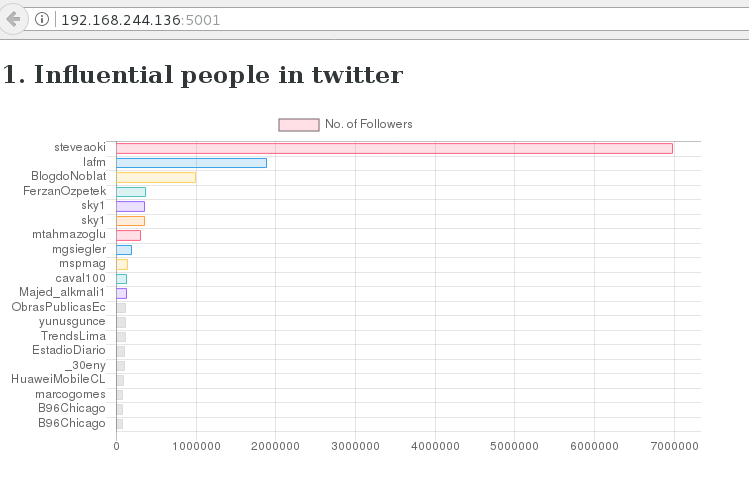

```python
from IPython.display import Image
Image(filename='HashtagsDashboard\\img\\1.png')
```

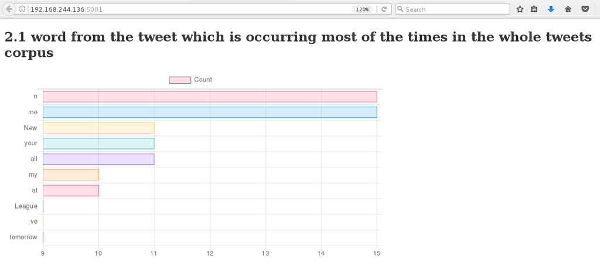

```python
from IPython.display import Image
Image(filename='HashtagsDashboard\\img\\2_1.png')
```

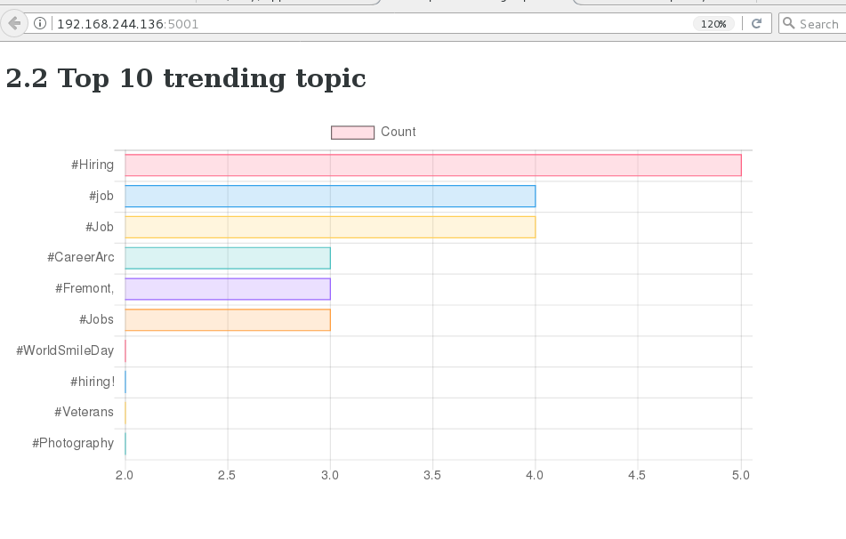

```python
from IPython.display import Image
Image(filename='HashtagsDashboard\\img\\2_2.png')
```

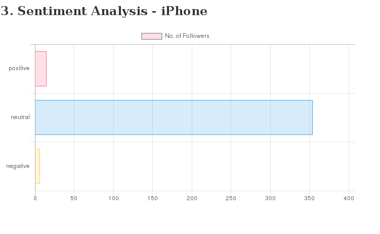

```python
from IPython.display import Image
Image(filename='HashtagsDashboard\\img\\3.png')
```

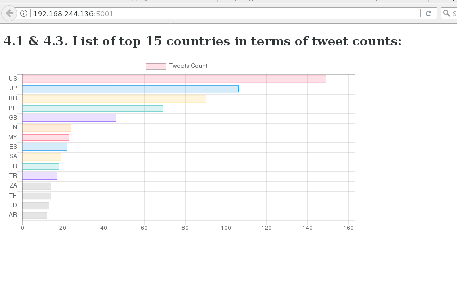

```python
from IPython.display import Image
Image(filename='HashtagsDashboard\\img\\4_1_3.png')
```

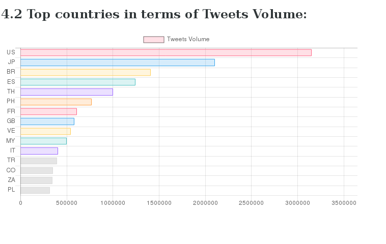

```python
from IPython.display import Image
Image(filename='HashtagsDashboard\\img\\4_2.png')
```

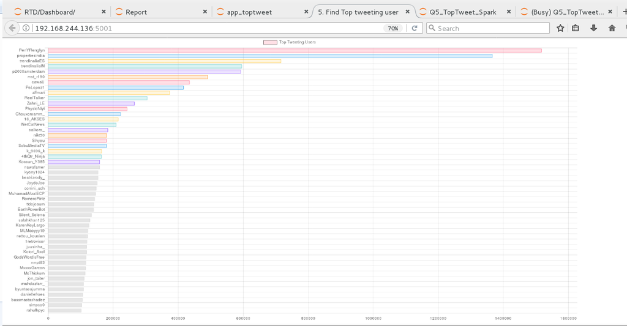

```python
from IPython.display import Image
Image(filename='HashtagsDashboard\\img\\5_1.png')
```

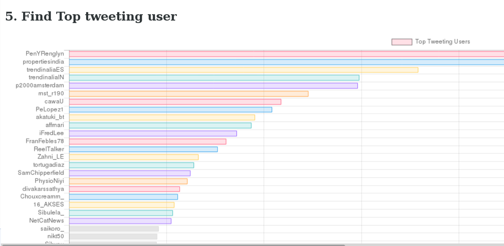

```python
from IPython.display import Image
Image(filename='HashtagsDashboard\\img\\5_2.png')
```

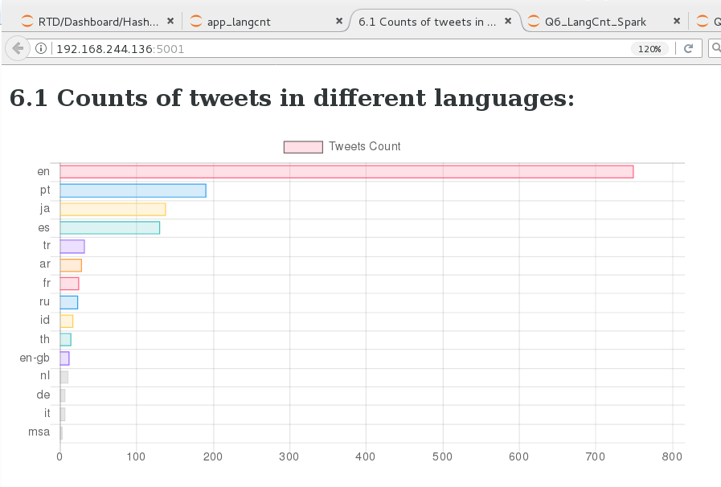

```python
from IPython.display import Image
Image(filename='HashtagsDashboard\\img\\6_1.png')
```

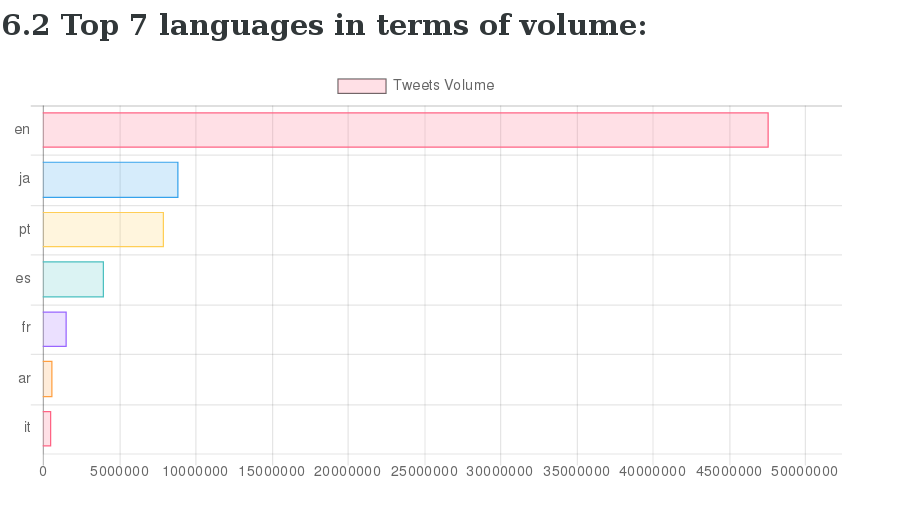

```python
from IPython.display import Image
Image(filename='HashtagsDashboard\\img\\6_2.png')
```

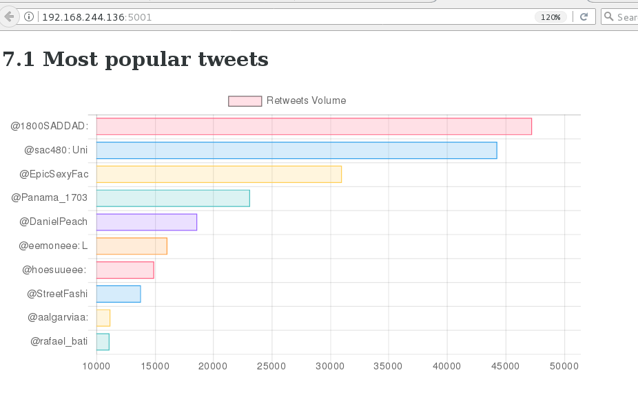

```python
from IPython.display import Image
Image(filename='HashtagsDashboard\\img\\7_1.png')
```

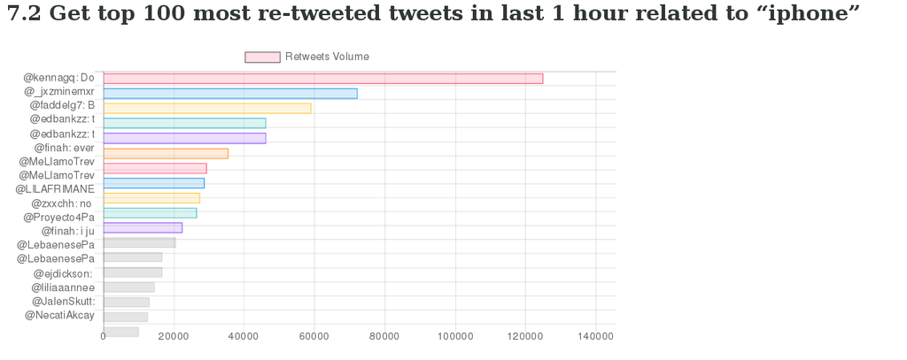

```python
from IPython.display import Image
Image(filename='HashtagsDashboard\\img\\7_2.png')
```